# Lesson 03: Descriptive Statistics

25 August, 2018

## 1.) Cars

> **Exercise 1**: mileage.csv is derived from a 1991 U.S EPA study of passenger car mileage. This file includes information on sixty cars: HP (engine horsepower), MPG (average miles per gallon) WT (vehicle weight in 100 lb units) and CLASS (vehicle weight class C1,.,C6).
- **Dataset**: *milage.csv*

```
## Observations: 60
## Variables: 5
## $ Make  <chr> "FordEscort", "HondaCivic", "PontiacLeMans", "IsuzuStylu...
## $ Hp    <int> 90, 92, 74, 95, 81, 95, 92, 92, 92, 103, 84, 84, 102, 10...
## $ Mpg   <dbl> 42.2, 40.9, 40.7, 40.0, 39.3, 38.8, 38.4, 38.4, 38.4, 36...
## $ Wt    <dbl> 25.0, 25.0, 25.0, 25.0, 25.0, 25.0, 25.0, 25.0, 25.0, 27...
## $ Class <ord> C1, C1, C1, C1, C1, C1, C1, C1, C1, C2, C2, C2, C2, C2, ...
```

### 1.1) Millage Summary

> For each weight class determine the mean and standard deviation of MPG. What can you conclude from these calculations?

```
##    Class      Avg    StdDev
## 1:    C1 39.67778 1.3608617
## 2:    C2 35.55000 0.5291503
## 3:    C3 32.01667 0.6293335
## 4:    C4 29.65833 2.1124989
## 5:    C5 23.85000 0.7728342
## 6:    C6 19.18571 2.7008817
```

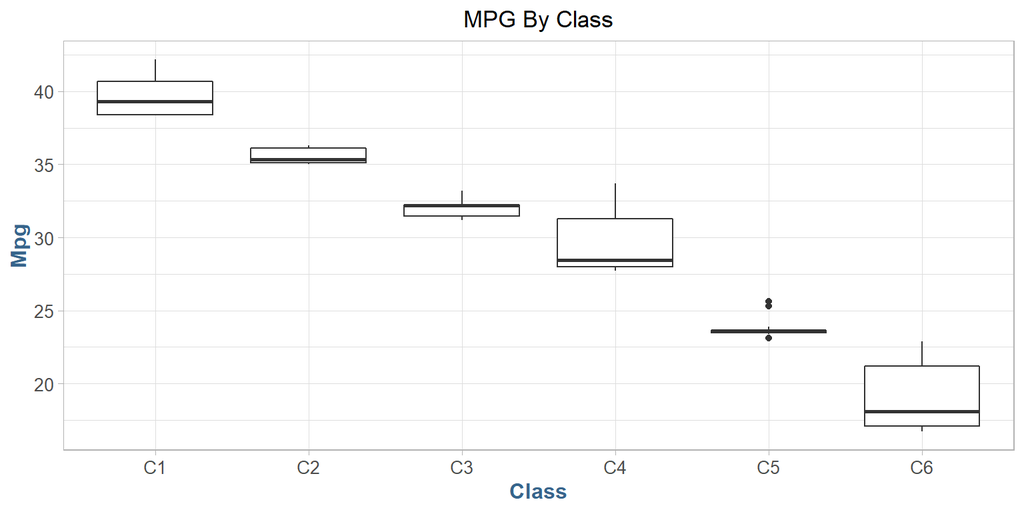

> **Answer**: There is a strong inverse correlation to MPG by weight class. This is an intuitive result, as one would expect the more a car weights, the less fuel efficient it is. There are minimal outliers in this data set, so we should have high relatively confidence in these results.

### 1.2) Horsepower Summary

> For each weight class determine the mean and standard deviation of HP. What can you conclude from these calculations?

```
##    Class       Avg    StdDev
## 1:    C1  89.22222  7.049429
## 2:    C2  92.00000  9.086882
## 3:    C3 103.50000 12.767145
## 4:    C4 123.83333 25.672176
## 5:    C5 171.58333 45.350069
## 6:    C6 224.71429 74.017372
```

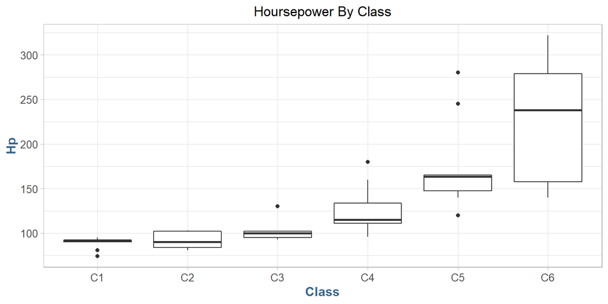

> **Answer**: There is a strong correlation from Horsepower to Weight Class. This makes intuitive sense as one would expect higher displacement engines, which typically have more horsepower, are housed in larger vehicles. This would of course not always be true, as race cars and specialty vehicles would be outliers in this data set. We also see many outliers in the C5 class, which suggest this could fit the profile of such a race car or special purpose vehicle.

## 2.) Shoppers

> **Exercise 2:**: shoppers.csv contains the dollar amounts spent in a store by individual shoppers during one day.

```
## Observations: 50
## Variables: 1
## $ Spending <dbl> 2.32, 6.61, 6.90, 8.04, 9.45, 10.26, 11.34, 11.63, 12...
```

> Find the mean, median, range, standard deviation, variance, Q1, Q3 and P10. Plot the histogram and describe the distribution.

```
##    Statistic     Value
## 1:      Mean  25.43640
## 2:    Median  20.73500
## 3:     Range  61.53000
## 4:    StdDev  15.20959
## 5:  Variance 231.33166
## 6:        Q1  14.39250
## 7:        Q3  33.66500
## 8:       P10  10.17900
```

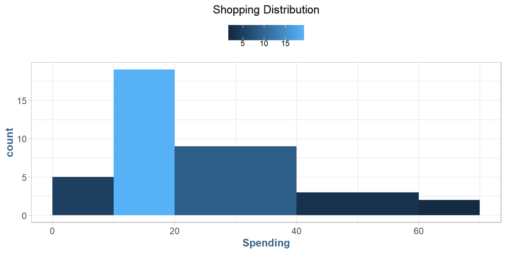

> **Answer**: The shopping distribution is heavily right-skewed, showing that most transactions were on the lower end, with a few big spenders sloping downward pretty linearly after around ~$20 (Assuming USD).

## 3.) POTUS

> **Exercise 3:** pontus.csv lists the ages of USA Presidents at the time of their inauguration. Also listed are the heights of the Presidents and their opponents.

### 3.1) Summary

> Find the mean, median, range, standard deviation, Q1, Q3 and P10 of the Presidents’ ages.

```
##    Statistic     Value
## 1:      Mean 54.763158
## 2:    Median 54.500000
## 3:     Range 27.000000
## 4:    StdDev  6.561288
## 5:  Variance 43.050498
## 6:        Q1 51.000000
## 7:        Q3 57.750000
## 8:       P10 46.700000
```

### 3.2) Opponents

> Find the mean, median, range, standard deviation, Q1, Q3 and P10 of the heights of the Presidents and also their opponents.

```
## $Ht
##    Statistic      Value
## 1:      Mean 179.684211
## 2:    Median 181.000000
## 3:     Range  30.000000
## 4:    StdDev   7.308289
## 5:  Variance  53.411095
## 6:        Q1 173.000000
## 7:        Q3 184.500000
## 8:       P10 170.000000
##
## $Htopp
##    Statistic      Value
## 1:      Mean 179.970588
## 2:    Median 180.000000
## 3:     Range  28.000000
## 4:    StdDev   6.201101
## 5:  Variance  38.453654
## 6:        Q1 175.500000
## 7:        Q3 182.750000
## 8:       P10 173.000000
```

### 3.3) Height Comparison

> Calculate the difference between each President’s height and that of his opponent. Plot a histogram of these differences. Construct a boxplot. What do you conclude from your calculations? Why is the difference of average heights calculated in (2) different from the average of the pairwise differences calculated in (3)?

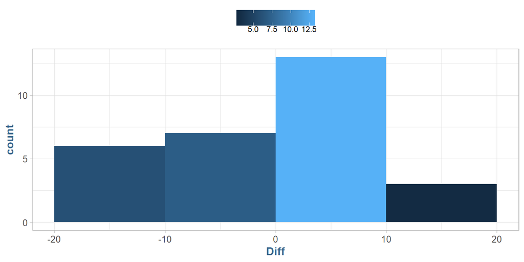

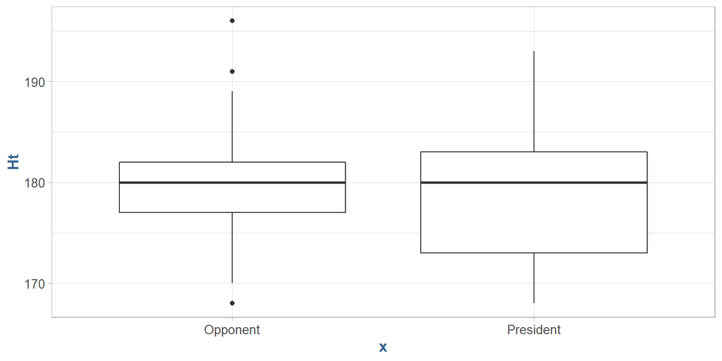

## 4.) Old Faithful

> **Exercise 4:** geyser.csv contains the intervals (in minutes) between eruptions of Old Faithful Geyser in Yellowstone National Park. The data were taken on two consecutive weeks: WEEK1 and WEEK2.

> Compare the two sets of data using summary(), hist() and boxplot().

```
##      Week1            Week2
##  Min.   : 43.00   Min.   :45.00
##  1st Qu.: 58.75   1st Qu.:63.25
##  Median : 75.00   Median :76.00
##  Mean   : 71.62   Mean   :72.76
##  3rd Qu.: 82.00   3rd Qu.:81.25
##  Max.   :108.00   Max.   :94.00
```

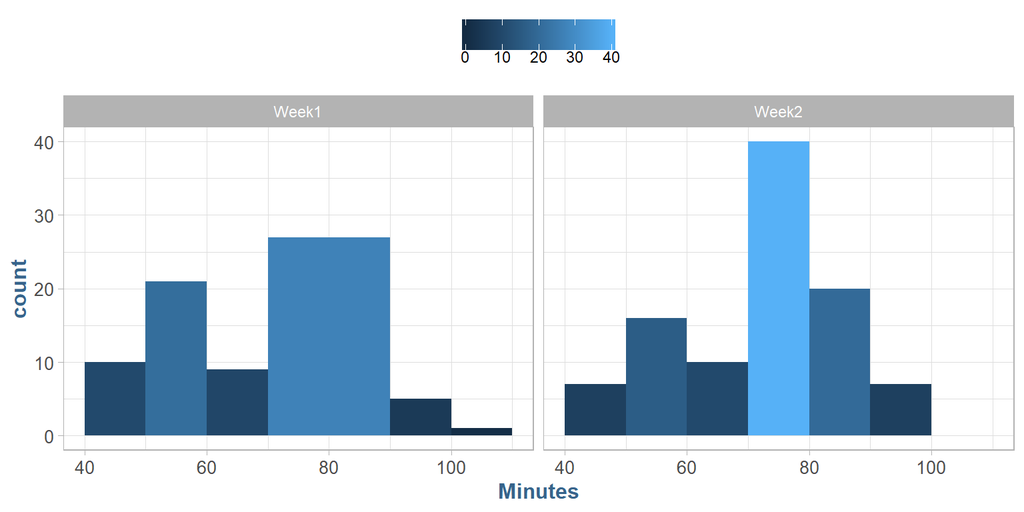

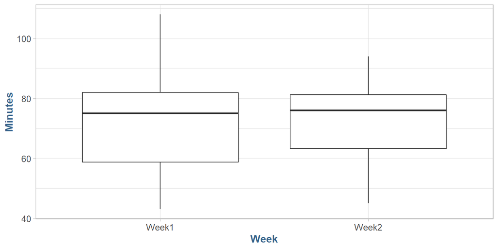

> What do you conclude?